# R course - WS22/23

Damian Wollny

Oktober 07, 2022

```r
library(tidyverse)
theme_set(theme_classic(base_size=18))
```

# A cross-country database of COVID-19 testing

**Paper**: https://www.nature.com/articles/s41597-020-00688-8#Sec7

**Data**: https://github.com/owid/covid-19-data/tree/master/public/data

About the paper:

“data can only be meaningfully interpreted alongside an accurate understanding of the extent of virus testing in different countries”

“The database is updated regularly”

“We rely on figures published in official sources, including press releases, government websites, dedicated dashboards, and social media accounts of national authorities”

## Data exploration

```r
# load data
cov2_data <- read.csv(file = "./owid-covid-data.csv") %>% as_tibble()
```

### Does the booster help?

Teaching problem: Vaccination is a sensitive topic

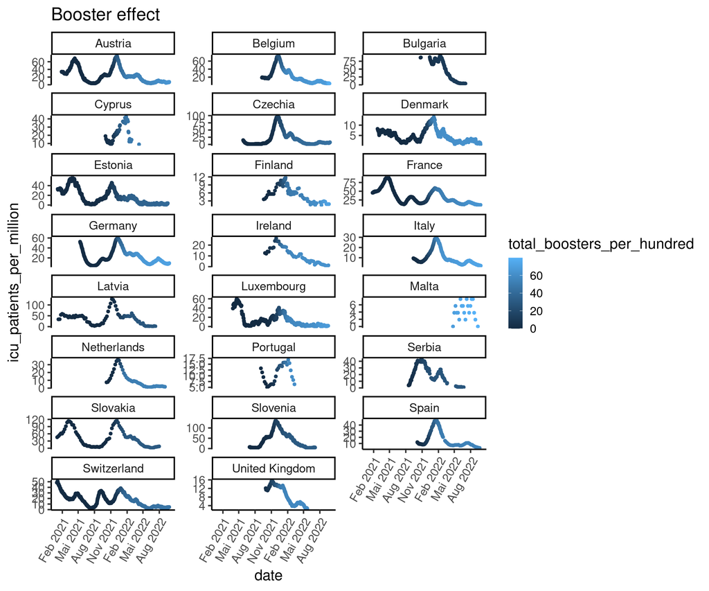

```r
cov2_data %>%
  filter(continent == "Europe") %>%
  mutate(date = as.Date(date)) %>%
  select(location, date, icu_patients_per_million, total_boosters_per_hundred) %>%
  drop_na() %>%
  ggplot(aes(x = date, y = icu_patients_per_million, color = total_boosters_per_hundred)) +
  geom_point() +
  scale_x_date(date_breaks = "3 month", date_labels =  "%b %Y") +
  theme(axis.text.x=element_text(angle=60, hjust=1))+
  facet_wrap(~location, scales = "free_y", ncol = 3) +
  labs(title = "Booster effect")
```

# Are things getting better?

Teaching problem: ‘date’ column needs to be converted using “as.Date”. Comes a bit too early

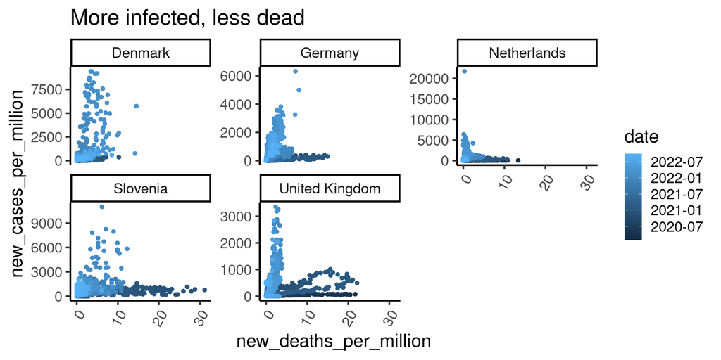

```r
test <- c("Netherlands", "Germany", "Denmark", "United Kingdom" , "Slovenia")

cov2_data %>%
  filter(continent == "Europe") %>%
  filter(location %in% test) %>%
  mutate(date = as.Date(date)) %>%
  select(location, date, new_cases_per_million, new_deaths_per_million ) %>%
  drop_na() %>%
  ggplot(aes(x = new_deaths_per_million, y = new_cases_per_million, color = date)) +
  geom_point() +
  #scale_x_date(date_breaks = "3 month", date_labels =  "%b %Y") +
  theme(axis.text.x=element_text(angle=60, hjust=1))+
  facet_wrap(~location, scales = "free_y", ncol = 3) +
  labs(title = "More infected, less dead")
```

# Does the number of cases depend on the population density?

Teaching problem: Plot might be too complicated in the sense that there are many concept you need to learn for it to be informative

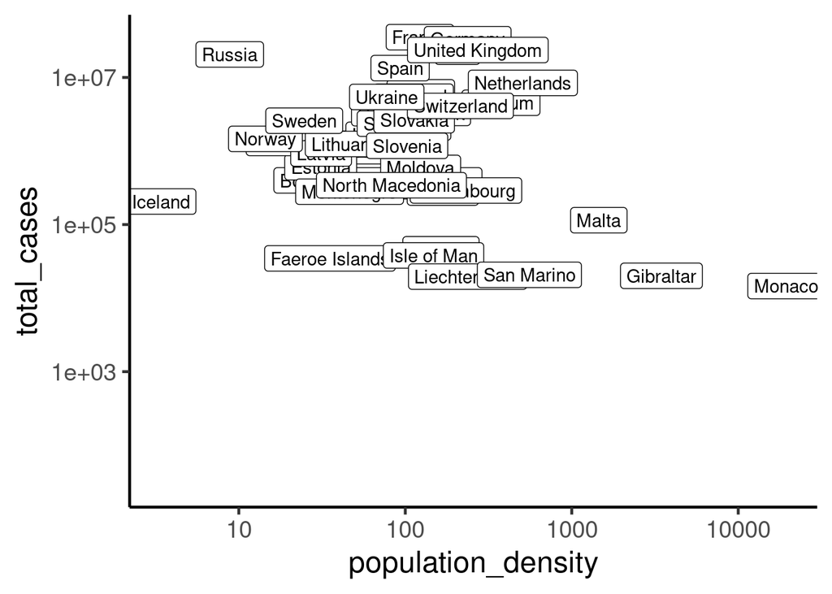

```r
cov2_data %>%
  filter(date == "2022-09-27") %>%
  filter(continent == "Europe") %>%
  select(location, date, population_density, total_cases) %>%
  ggplot(aes(x = population_density, y = total_cases, label = location)) +
  geom_point() +
  geom_label() +
  scale_y_continuous(trans = "log10") +
  scale_x_continuous(trans = "log10")
```

# Does the number of cases depend on the population age?

This could be interesting

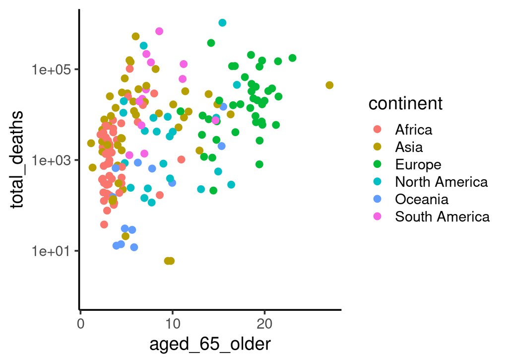

```r
cov2_data %>%
  na_if("") %>%
  drop_na(continent) %>%
  filter(date == "2022-09-27") %>%
  select(location, aged_65_older, total_deaths, continent) %>%
  ggplot(aes(x = aged_65_older, y = total_deaths, color = continent)) +
  geom_point(size = 3) +
  scale_y_continuous(trans = "log10")
```

# Are the rich countries dying less?

Teaching problem: Difficult to interpret. Could very well be a ‘missing data’/‘insufficient testing’ problem

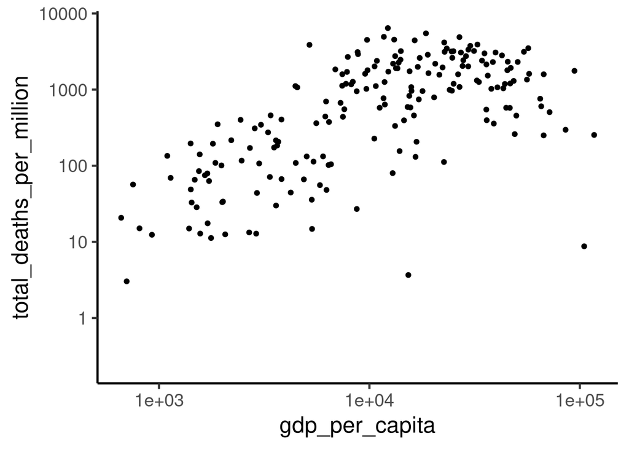

```r
cov2_data %>%
  filter(date == "2022-09-27") %>%
  #filter(continent == "Europe") %>%
  select(location, date, total_deaths_per_million, gdp_per_capita) %>%
  ggplot(aes(x = gdp_per_capita, y = total_deaths_per_million, label = location)) +
  geom_point() +
  #geom_label() +
  scale_y_continuous(trans = "log10") +
  scale_x_continuous(trans = "log10")
```

# Do people in more developed countries live longer?

A good plot to show what a good correlation looks like (and is) + fit a regression line if needed

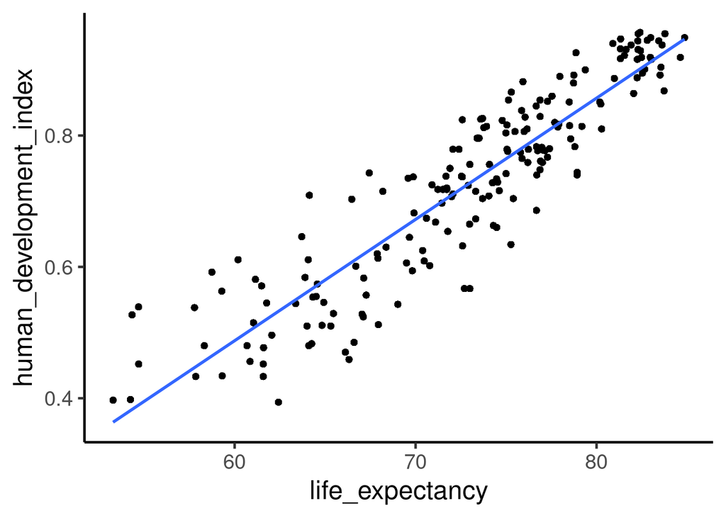

```r
cov2_data %>%
  drop_na(human_development_index) %>%
  ggplot(aes(x=life_expectancy, y=human_development_index)) +
  geom_point() +
  geom_smooth(method='lm')
```

# Does covid display any indications of seasonality?

Students will make a lineplot + use the colour= attribute. Perhaps makes sense to display more dates on x axis. Based on a lmited number of countries, it seems covid does exhibit certain patterns (also https://doi.org/10.1016/j.envres.2021.112614 & https://doi.org/10.1186/s12879-021-06785-2)

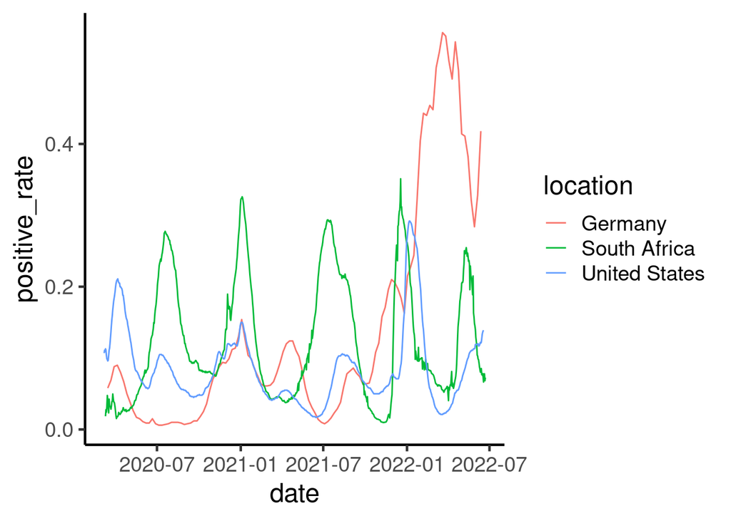

```r
cov2_data %>%
  filter(location %in% c("United States", "South Africa", "Germany")) %>%
  drop_na(positive_rate) %>%
  mutate(date = as.Date(date)) %>%
  ggplot(aes(x=date, y=positive_rate, colour=location)) +
  geom_line()
```

# How many new tests were conducted in Germany?

Germany positive rate has gone up fast as seen in the last plot. Does that mean the number of tests decreased? We filter for dates after January this year and see that number of new tests fluctuates and isn’t well correlated with the positive rate, hence showing a real surge in cases for that time period.

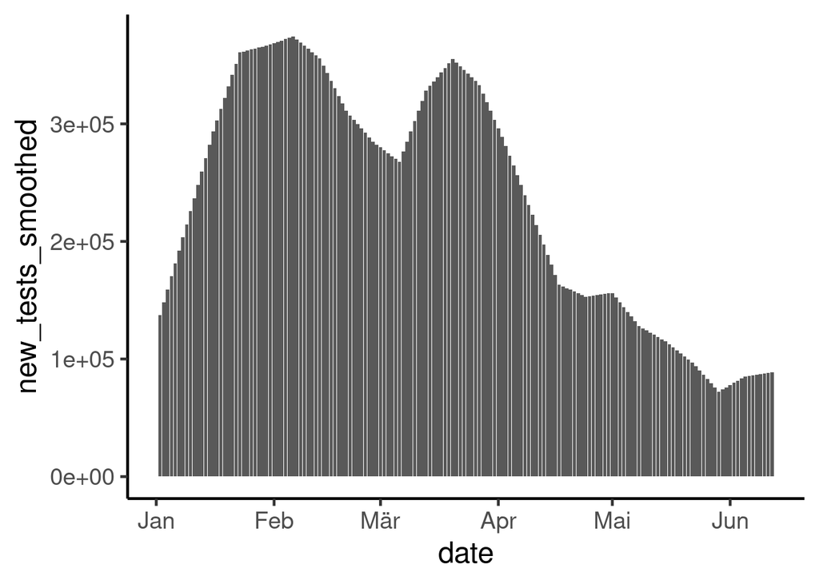

```r
cov2_data %>%
  filter(location == "Germany") %>%
  drop_na(new_tests_smoothed) %>%
  mutate(date = as.Date(date)) %>%
  filter(date>"2022-01-01") %>%
  ggplot(aes(x=date, y=new_tests_smoothed)) +
  geom_col()
```